# Risk Factor Analysis

## Outcome Variable

**Outcome Variable:** ever_co

## Predictor Variables

**Intervention Variable:** feducyrs

**Adjustment Set:**

- arm
- W_mage
- meducyrs
- hhwealth_quart
- W_mhtcm
- W_gagebrth
- W_birthwt
- W_birthlen
- single
- delta_W_mage
- delta_meducyrs
- delta_hhwealth_quart
- delta_W_mhtcm
- delta_W_gagebrth
- delta_W_birthwt
- delta_W_birthlen
- delta_single

## Stratifying Variables

The analysis was stratified on these variable(s):

- agecat
- studyid
- country

## Data Summary

| agecat | studyid | country | feducyrs | ever_co | n_cell | n |
| --- | --- | --- | --- | --- | --- | --- |
| 0-24 months | ki0047075b-MAL-ED | BANGLADESH | High | 0 | 50 | 147 |
| 0-24 months | ki0047075b-MAL-ED | BANGLADESH | High | 1 | 4 | 147 |
| 0-24 months | ki0047075b-MAL-ED | BANGLADESH | Low | 0 | 33 | 147 |
| 0-24 months | ki0047075b-MAL-ED | BANGLADESH | Low | 1 | 6 | 147 |
| 0-24 months | ki0047075b-MAL-ED | BANGLADESH | Medium | 0 | 45 | 147 |
| 0-24 months | ki0047075b-MAL-ED | BANGLADESH | Medium | 1 | 9 | 147 |
| 0-24 months | ki0047075b-MAL-ED | INDIA | High | 0 | 36 | 147 |
| 0-24 months | ki0047075b-MAL-ED | INDIA | High | 1 | 8 | 147 |
| 0-24 months | ki0047075b-MAL-ED | INDIA | Low | 0 | 46 | 147 |
| 0-24 months | ki0047075b-MAL-ED | INDIA | Low | 1 | 13 | 147 |
| 0-24 months | ki0047075b-MAL-ED | INDIA | Medium | 0 | 36 | 147 |
| 0-24 months | ki0047075b-MAL-ED | INDIA | Medium | 1 | 8 | 147 |
| 0-24 months | ki0047075b-MAL-ED | NEPAL | High | 0 | 39 | 98 |
| 0-24 months | ki0047075b-MAL-ED | NEPAL | High | 1 | 3 | 98 |
| 0-24 months | ki0047075b-MAL-ED | NEPAL | Low | 0 | 26 | 98 |
| 0-24 months | ki0047075b-MAL-ED | NEPAL | Low | 1 | 2 | 98 |
| 0-24 months | ki0047075b-MAL-ED | NEPAL | Medium | 0 | 22 | 98 |
| 0-24 months | ki0047075b-MAL-ED | NEPAL | Medium | 1 | 6 | 98 |
| 0-24 months | ki0047075b-MAL-ED | PERU | High | 0 | 116 | 250 |
| 0-24 months | ki0047075b-MAL-ED | PERU | High | 1 | 4 | 250 |
| 0-24 months | ki0047075b-MAL-ED | PERU | Low | 0 | 68 | 250 |
| 0-24 months | ki0047075b-MAL-ED | PERU | Low | 1 | 1 | 250 |
| 0-24 months | ki0047075b-MAL-ED | PERU | Medium | 0 | 58 | 250 |
| 0-24 months | ki0047075b-MAL-ED | PERU | Medium | 1 | 3 | 250 |
| 0-24 months | ki0047075b-MAL-ED | SOUTH AFRICA | High | 0 | 40 | 110 |
| 0-24 months | ki0047075b-MAL-ED | SOUTH AFRICA | High | 1 | 3 | 110 |
| 0-24 months | ki0047075b-MAL-ED | SOUTH AFRICA | Low | 0 | 34 | 110 |
| 0-24 months | ki0047075b-MAL-ED | SOUTH AFRICA | Low | 1 | 3 | 110 |
| 0-24 months | ki0047075b-MAL-ED | SOUTH AFRICA | Medium | 0 | 27 | 110 |
| 0-24 months | ki0047075b-MAL-ED | SOUTH AFRICA | Medium | 1 | 3 | 110 |

[output cut: 330 more lines]

The following strata were considered:

- agecat: 0-24 months, studyid: ki0047075b-MAL-ED, country: BANGLADESH
- agecat: 0-24 months, studyid: ki0047075b-MAL-ED, country: INDIA
- agecat: 0-24 months, studyid: ki0047075b-MAL-ED, country: NEPAL
- agecat: 0-24 months, studyid: ki0047075b-MAL-ED, country: PERU
- agecat: 0-24 months, studyid: ki0047075b-MAL-ED, country: SOUTH AFRICA
- agecat: 0-24 months, studyid: ki0047075b-MAL-ED, country: TANZANIA, UNITED REPUBLIC OF
- agecat: 0-24 months, studyid: ki1000304b-SAS-CompFeed, country: INDIA
- agecat: 0-24 months, studyid: ki1000304b-SAS-FoodSuppl, country: INDIA
- agecat: 0-24 months, studyid: ki1017093b-PROVIDE, country: BANGLADESH
- agecat: 0-24 months, studyid: ki1017093c-NIH-Crypto, country: BANGLADESH
- agecat: 0-24 months, studyid: ki1066203-TanzaniaChild2, country: TANZANIA, UNITED REPUBLIC OF
- agecat: 0-24 months, studyid: ki1113344-GMS-Nepal, country: NEPAL
- agecat: 0-24 months, studyid: ki1119695-PROBIT, country: BELARUS
- agecat: 0-24 months, studyid: ki1126311-ZVITAMBO, country: ZIMBABWE
- agecat: 0-24 months, studyid: ki1135781-COHORTS, country: GUATEMALA
- agecat: 0-24 months, studyid: ki1135781-COHORTS, country: INDIA
- agecat: 0-24 months, studyid: ki1135781-COHORTS, country: PHILIPPINES
- agecat: 0-24 months, studyid: ki1148112-LCNI-5, country: MALAWI
- agecat: 0-24 months, studyid: kiGH5241-JiVitA-3, country: BANGLADESH
- agecat: 0-24 months, studyid: kiGH5241-JiVitA-4, country: BANGLADESH
- agecat: 0-6 months, studyid: ki0047075b-MAL-ED, country: BANGLADESH
- agecat: 0-6 months, studyid: ki0047075b-MAL-ED, country: INDIA
- agecat: 0-6 months, studyid: ki0047075b-MAL-ED, country: NEPAL
- agecat: 0-6 months, studyid: ki0047075b-MAL-ED, country: PERU
- agecat: 0-6 months, studyid: ki0047075b-MAL-ED, country: SOUTH AFRICA
- agecat: 0-6 months, studyid: ki0047075b-MAL-ED, country: TANZANIA, UNITED REPUBLIC OF
- agecat: 0-6 months, studyid: ki1000304b-SAS-CompFeed, country: INDIA
- agecat: 0-6 months, studyid: ki1000304b-SAS-FoodSuppl, country: INDIA
- agecat: 0-6 months, studyid: ki1017093b-PROVIDE, country: BANGLADESH
- agecat: 0-6 months, studyid: ki1017093c-NIH-Crypto, country: BANGLADESH
- agecat: 0-6 months, studyid: ki1066203-TanzaniaChild2, country: TANZANIA, UNITED REPUBLIC OF
- agecat: 0-6 months, studyid: ki1113344-GMS-Nepal, country: NEPAL
- agecat: 0-6 months, studyid: ki1119695-PROBIT, country: BELARUS
- agecat: 0-6 months, studyid: ki1126311-ZVITAMBO, country: ZIMBABWE
- agecat: 0-6 months, studyid: ki1135781-COHORTS, country: GUATEMALA
- agecat: 0-6 months, studyid: ki1135781-COHORTS, country: INDIA
- agecat: 0-6 months, studyid: ki1135781-COHORTS, country: PHILIPPINES
- agecat: 0-6 months, studyid: ki1148112-LCNI-5, country: MALAWI
- agecat: 0-6 months, studyid: kiGH5241-JiVitA-3, country: BANGLADESH
- agecat: 0-6 months, studyid: kiGH5241-JiVitA-4, country: BANGLADESH
- agecat: 6-24 months, studyid: ki0047075b-MAL-ED, country: BANGLADESH
- agecat: 6-24 months, studyid: ki0047075b-MAL-ED, country: INDIA
- agecat: 6-24 months, studyid: ki0047075b-MAL-ED, country: NEPAL
- agecat: 6-24 months, studyid: ki0047075b-MAL-ED, country: PERU
- agecat: 6-24 months, studyid: ki0047075b-MAL-ED, country: SOUTH AFRICA
- agecat: 6-24 months, studyid: ki0047075b-MAL-ED, country: TANZANIA, UNITED REPUBLIC OF
- agecat: 6-24 months, studyid: ki1000304b-SAS-CompFeed, country: INDIA
- agecat: 6-24 months, studyid: ki1000304b-SAS-FoodSuppl, country: INDIA
- agecat: 6-24 months, studyid: ki1017093b-PROVIDE, country: BANGLADESH
- agecat: 6-24 months, studyid: ki1017093c-NIH-Crypto, country: BANGLADESH
- agecat: 6-24 months, studyid: ki1066203-TanzaniaChild2, country: TANZANIA, UNITED REPUBLIC OF
- agecat: 6-24 months, studyid: ki1113344-GMS-Nepal, country: NEPAL
- agecat: 6-24 months, studyid: ki1119695-PROBIT, country: BELARUS
- agecat: 6-24 months, studyid: ki1126311-ZVITAMBO, country: ZIMBABWE
- agecat: 6-24 months, studyid: ki1135781-COHORTS, country: GUATEMALA
- agecat: 6-24 months, studyid: ki1135781-COHORTS, country: INDIA
- agecat: 6-24 months, studyid: ki1135781-COHORTS, country: PHILIPPINES
- agecat: 6-24 months, studyid: ki1148112-LCNI-5, country: MALAWI
- agecat: 6-24 months, studyid: kiGH5241-JiVitA-3, country: BANGLADESH
- agecat: 6-24 months, studyid: kiGH5241-JiVitA-4, country: BANGLADESH

### Dropped Strata

Some strata were dropped due to rare outcomes:

- agecat: 0-24 months, studyid: ki0047075b-MAL-ED, country: BANGLADESH
- agecat: 0-24 months, studyid: ki0047075b-MAL-ED, country: NEPAL
- agecat: 0-24 months, studyid: ki0047075b-MAL-ED, country: PERU
- agecat: 0-24 months, studyid: ki0047075b-MAL-ED, country: SOUTH AFRICA
- agecat: 0-24 months, studyid: ki0047075b-MAL-ED, country: TANZANIA, UNITED REPUBLIC OF
- agecat: 0-24 months, studyid: ki1119695-PROBIT, country: BELARUS
- agecat: 0-6 months, studyid: ki0047075b-MAL-ED, country: BANGLADESH
- agecat: 0-6 months, studyid: ki0047075b-MAL-ED, country: INDIA
- agecat: 0-6 months, studyid: ki0047075b-MAL-ED, country: NEPAL
- agecat: 0-6 months, studyid: ki0047075b-MAL-ED, country: PERU
- agecat: 0-6 months, studyid: ki0047075b-MAL-ED, country: SOUTH AFRICA
- agecat: 0-6 months, studyid: ki0047075b-MAL-ED, country: TANZANIA, UNITED REPUBLIC OF
- agecat: 0-6 months, studyid: ki1017093c-NIH-Crypto, country: BANGLADESH
- agecat: 0-6 months, studyid: ki1066203-TanzaniaChild2, country: TANZANIA, UNITED REPUBLIC OF
- agecat: 0-6 months, studyid: ki1119695-PROBIT, country: BELARUS
- agecat: 0-6 months, studyid: ki1135781-COHORTS, country: GUATEMALA
- agecat: 0-6 months, studyid: ki1148112-LCNI-5, country: MALAWI
- agecat: 0-6 months, studyid: kiGH5241-JiVitA-4, country: BANGLADESH
- agecat: 6-24 months, studyid: ki0047075b-MAL-ED, country: BANGLADESH
- agecat: 6-24 months, studyid: ki0047075b-MAL-ED, country: NEPAL
- agecat: 6-24 months, studyid: ki0047075b-MAL-ED, country: PERU
- agecat: 6-24 months, studyid: ki0047075b-MAL-ED, country: SOUTH AFRICA
- agecat: 6-24 months, studyid: ki0047075b-MAL-ED, country: TANZANIA, UNITED REPUBLIC OF
- agecat: 6-24 months, studyid: ki1119695-PROBIT, country: BELARUS

## Methods Detail

We’re interested in the causal parameters $E[Y_a]$ for all values of $a \in \mathcal{A}$. These parameters represent the mean outcome if, possibly contrary to fact, we intervened to set all units to have $A=a$. Under the randomization and positivity assumptions, these are identified by the statistical parameters $\psi_a=E_W[E_{Y|A,W}(Y|A=a,W)]$. In addition, we’re interested in the mean of $Y$, $E[Y]$ under no intervention (the observed mean). We will estimate these parameters by using SuperLearner to fit the relevant likelihood factors – $E_{Y|A,W}(Y|A=a,W)$ and $p(A=a|W)$, and then updating our likelihood fit using a joint TMLE.

For unadjusted analyses ($W=\{\}$), initial likelihoods were estimated using Lrnr_glm to estimate the simple $E(Y|A)$ and Lrnr_mean to estimate $p(A)$. For adjusted analyses, a small library containing Lrnr_glmnet, Lrnr_xgboost, and Lrnr_mean was used.

Having estimated these parameters, we will then use the delta method to estimate relative risks and attributable risks relative to a prespecified baseline level of $A$.

# Results Detail

## Results Plots

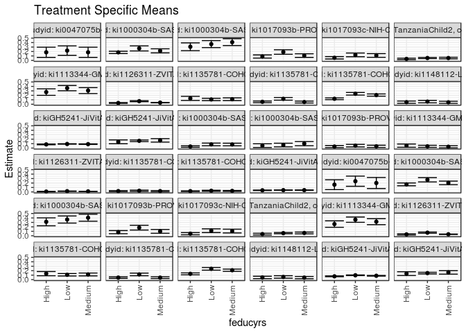

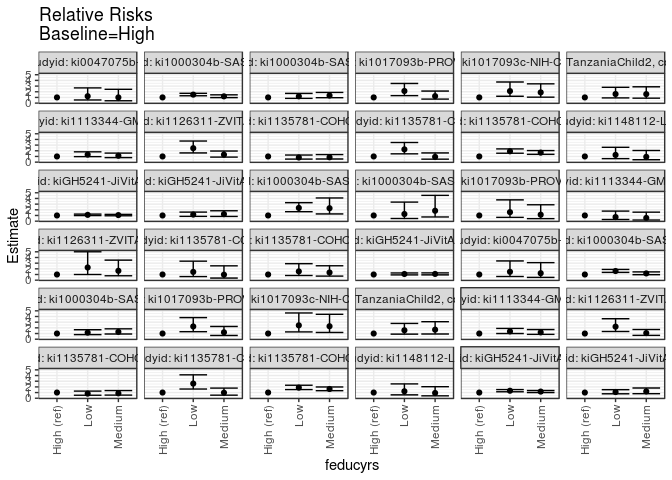

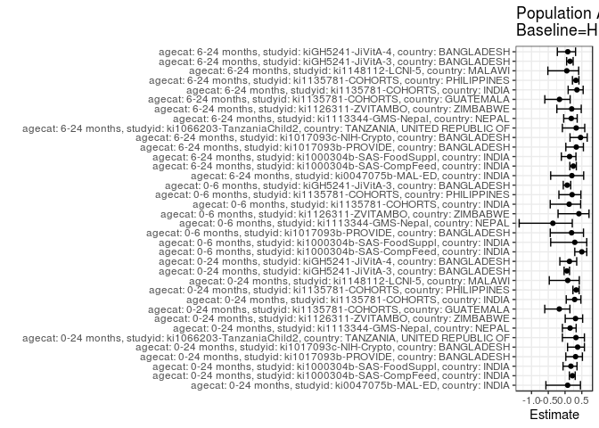

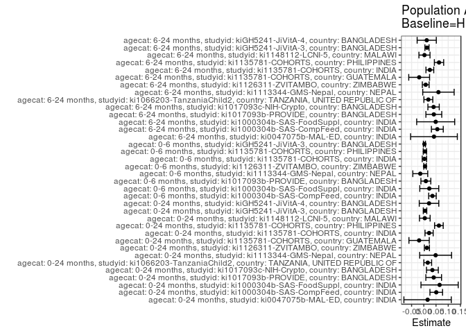

## Results Table

### Parameter: TSM

| agecat | studyid | country | intervention_level | baseline_level | estimate | ci_lower | ci_upper |
| --- | --- | --- | --- | --- | --- | --- | --- |
| 0-24 months | ki0047075b-MAL-ED | INDIA | High | NA | 0.1818182 | 0.0674652 | 0.2961712 |
| 0-24 months | ki0047075b-MAL-ED | INDIA | Low | NA | 0.2203390 | 0.1142176 | 0.3264604 |
| 0-24 months | ki0047075b-MAL-ED | INDIA | Medium | NA | 0.1818182 | 0.0674652 | 0.2961712 |
| 0-24 months | ki1000304b-SAS-CompFeed | INDIA | High | NA | 0.1801765 | 0.1535653 | 0.2067877 |
| 0-24 months | ki1000304b-SAS-CompFeed | INDIA | Low | NA | 0.2693262 | 0.2124223 | 0.3262300 |
| 0-24 months | ki1000304b-SAS-CompFeed | INDIA | Medium | NA | 0.2145458 | 0.1691191 | 0.2599725 |
| 0-24 months | ki1000304b-SAS-FoodSuppl | INDIA | High | NA | 0.3061497 | 0.2186374 | 0.3936619 |
| 0-24 months | ki1000304b-SAS-FoodSuppl | INDIA | Low | NA | 0.3658323 | 0.2873195 | 0.4443452 |
| 0-24 months | ki1000304b-SAS-FoodSuppl | INDIA | Medium | NA | 0.4096831 | 0.3333034 | 0.4860627 |
| 0-24 months | ki1017093b-PROVIDE | BANGLADESH | High | NA | 0.0881257 | 0.0527313 | 0.1235202 |
| 0-24 months | ki1017093b-PROVIDE | BANGLADESH | Low | NA | 0.1882458 | 0.1379156 | 0.2385759 |
| 0-24 months | ki1017093b-PROVIDE | BANGLADESH | Medium | NA | 0.1079956 | 0.0674656 | 0.1485256 |
| 0-24 months | ki1017093c-NIH-Crypto | BANGLADESH | High | NA | 0.0585152 | 0.0320512 | 0.0849793 |
| 0-24 months | ki1017093c-NIH-Crypto | BANGLADESH | Low | NA | 0.1238013 | 0.0820544 | 0.1655482 |
| 0-24 months | ki1017093c-NIH-Crypto | BANGLADESH | Medium | NA | 0.1103014 | 0.0688878 | 0.1517149 |
| 0-24 months | ki1066203-TanzaniaChild2 | TANZANIA, UNITED REPUBLIC OF | High | NA | 0.0334078 | 0.0166125 | 0.0502032 |
| 0-24 months | ki1066203-TanzaniaChild2 | TANZANIA, UNITED REPUBLIC OF | Low | NA | 0.0533989 | 0.0409889 | 0.0658089 |
| 0-24 months | ki1066203-TanzaniaChild2 | TANZANIA, UNITED REPUBLIC OF | Medium | NA | 0.0528142 | 0.0356987 | 0.0699298 |
| 0-24 months | ki1113344-GMS-Nepal | NEPAL | High | NA | 0.2727224 | 0.1994666 | 0.3459782 |
| 0-24 months | ki1113344-GMS-Nepal | NEPAL | Low | NA | 0.3620016 | 0.3026702 | 0.4213330 |
| 0-24 months | ki1113344-GMS-Nepal | NEPAL | Medium | NA | 0.3066825 | 0.2401692 | 0.3731958 |
| 0-24 months | ki1126311-ZVITAMBO | ZIMBABWE | High | NA | 0.0279082 | 0.0173283 | 0.0384881 |
| 0-24 months | ki1126311-ZVITAMBO | ZIMBABWE | Low | NA | 0.0685136 | 0.0567928 | 0.0802343 |
| 0-24 months | ki1126311-ZVITAMBO | ZIMBABWE | Medium | NA | 0.0367794 | 0.0329836 | 0.0405753 |
| 0-24 months | ki1135781-COHORTS | GUATEMALA | High | NA | 0.1319598 | 0.0858216 | 0.1780980 |
| 0-24 months | ki1135781-COHORTS | GUATEMALA | Low | NA | 0.1077766 | 0.0818821 | 0.1336711 |
| 0-24 months | ki1135781-COHORTS | GUATEMALA | Medium | NA | 0.1130146 | 0.0828123 | 0.1432168 |
| 0-24 months | ki1135781-COHORTS | INDIA | High | NA | 0.0536918 | 0.0347576 | 0.0726261 |
| 0-24 months | ki1135781-COHORTS | INDIA | Low | NA | 0.1207251 | 0.0907347 | 0.1507156 |
| 0-24 months | ki1135781-COHORTS | INDIA | Medium | NA | 0.0493048 | 0.0273654 | 0.0712443 |

[output cut: 78 more lines]

### Parameter: E(Y)

| agecat | studyid | country | intervention_level | baseline_level | estimate | ci_lower | ci_upper |
| --- | --- | --- | --- | --- | --- | --- | --- |
| 0-24 months | ki0047075b-MAL-ED | INDIA | NA | NA | 0.1972789 | 0.1327292 | 0.2618286 |
| 0-24 months | ki1000304b-SAS-CompFeed | INDIA | NA | NA | 0.2311258 | 0.1911027 | 0.2711489 |
| 0-24 months | ki1000304b-SAS-FoodSuppl | INDIA | NA | NA | 0.3708134 | 0.3244530 | 0.4171738 |
| 0-24 months | ki1017093b-PROVIDE | BANGLADESH | NA | NA | 0.1285714 | 0.1037574 | 0.1533855 |
| 0-24 months | ki1017093c-NIH-Crypto | BANGLADESH | NA | NA | 0.0936675 | 0.0729118 | 0.1144233 |
| 0-24 months | ki1066203-TanzaniaChild2 | TANZANIA, UNITED REPUBLIC OF | NA | NA | 0.0495174 | 0.0408052 | 0.0582296 |
| 0-24 months | ki1113344-GMS-Nepal | NEPAL | NA | NA | 0.3211314 | 0.2837715 | 0.3584914 |
| 0-24 months | ki1126311-ZVITAMBO | ZIMBABWE | NA | NA | 0.0406402 | 0.0373164 | 0.0439640 |
| 0-24 months | ki1135781-COHORTS | GUATEMALA | NA | NA | 0.1126418 | 0.0949950 | 0.1302886 |
| 0-24 months | ki1135781-COHORTS | INDIA | NA | NA | 0.0753283 | 0.0617252 | 0.0889313 |
| 0-24 months | ki1135781-COHORTS | PHILIPPINES | NA | NA | 0.1847978 | 0.1705903 | 0.1990052 |
| 0-24 months | ki1148112-LCNI-5 | MALAWI | NA | NA | 0.0504305 | 0.0353790 | 0.0654820 |
| 0-24 months | kiGH5241-JiVitA-3 | BANGLADESH | NA | NA | 0.0879235 | 0.0839809 | 0.0918662 |
| 0-24 months | kiGH5241-JiVitA-4 | BANGLADESH | NA | NA | 0.1614685 | 0.1457688 | 0.1771681 |
| 0-6 months | ki1000304b-SAS-CompFeed | INDIA | NA | NA | 0.0706196 | 0.0480792 | 0.0931600 |
| 0-6 months | ki1000304b-SAS-FoodSuppl | INDIA | NA | NA | 0.0769231 | 0.0512858 | 0.1025603 |
| 0-6 months | ki1017093b-PROVIDE | BANGLADESH | NA | NA | 0.0428571 | 0.0278427 | 0.0578716 |
| 0-6 months | ki1113344-GMS-Nepal | NEPAL | NA | NA | 0.0399334 | 0.0242662 | 0.0556006 |
| 0-6 months | ki1126311-ZVITAMBO | ZIMBABWE | NA | NA | 0.0121055 | 0.0102583 | 0.0139526 |
| 0-6 months | ki1135781-COHORTS | INDIA | NA | NA | 0.0204658 | 0.0130911 | 0.0278404 |
| 0-6 months | ki1135781-COHORTS | PHILIPPINES | NA | NA | 0.0212766 | 0.0159935 | 0.0265597 |
| 0-6 months | kiGH5241-JiVitA-3 | BANGLADESH | NA | NA | 0.0390404 | 0.0364968 | 0.0415841 |
| 6-24 months | ki0047075b-MAL-ED | INDIA | NA | NA | 0.2043796 | 0.1366076 | 0.2721516 |
| 6-24 months | ki1000304b-SAS-CompFeed | INDIA | NA | NA | 0.2251082 | 0.1905625 | 0.2596539 |
| 6-24 months | ki1000304b-SAS-FoodSuppl | INDIA | NA | NA | 0.3615960 | 0.3145115 | 0.4086805 |
| 6-24 months | ki1017093b-PROVIDE | BANGLADESH | NA | NA | 0.1221498 | 0.0962275 | 0.1480722 |
| 6-24 months | ki1017093c-NIH-Crypto | BANGLADESH | NA | NA | 0.0863014 | 0.0659171 | 0.1066856 |
| 6-24 months | ki1066203-TanzaniaChild2 | TANZANIA, UNITED REPUBLIC OF | NA | NA | 0.0557769 | 0.0457368 | 0.0658170 |
| 6-24 months | ki1113344-GMS-Nepal | NEPAL | NA | NA | 0.3225806 | 0.2847967 | 0.3603646 |
| 6-24 months | ki1126311-ZVITAMBO | ZIMBABWE | NA | NA | 0.0391911 | 0.0354588 | 0.0429235 |
| 6-24 months | ki1135781-COHORTS | GUATEMALA | NA | NA | 0.1147687 | 0.0961264 | 0.1334109 |
| 6-24 months | ki1135781-COHORTS | INDIA | NA | NA | 0.0697509 | 0.0564268 | 0.0830750 |
| 6-24 months | ki1135781-COHORTS | PHILIPPINES | NA | NA | 0.1917860 | 0.1768046 | 0.2067673 |
| 6-24 months | ki1148112-LCNI-5 | MALAWI | NA | NA | 0.0511222 | 0.0358697 | 0.0663747 |
| 6-24 months | kiGH5241-JiVitA-3 | BANGLADESH | NA | NA | 0.0864979 | 0.0817318 | 0.0912639 |
| 6-24 months | kiGH5241-JiVitA-4 | BANGLADESH | NA | NA | 0.1465321 | 0.1312221 | 0.1618420 |

### Parameter: RR

| agecat | studyid | country | intervention_level | baseline_level | estimate | ci_lower | ci_upper |
| --- | --- | --- | --- | --- | --- | --- | --- |
| 0-24 months | ki0047075b-MAL-ED | INDIA | High | High | 1.0000000 | 1.0000000 | 1.000000 |
| 0-24 months | ki0047075b-MAL-ED | INDIA | Low | High | 1.2118644 | 0.5488063 | 2.676017 |
| 0-24 months | ki0047075b-MAL-ED | INDIA | Medium | High | 1.0000000 | 0.4108786 | 2.433809 |
| 0-24 months | ki1000304b-SAS-CompFeed | INDIA | High | High | 1.0000000 | 1.0000000 | 1.000000 |
| 0-24 months | ki1000304b-SAS-CompFeed | INDIA | Low | High | 1.4947906 | 1.2921031 | 1.729273 |
| 0-24 months | ki1000304b-SAS-CompFeed | INDIA | Medium | High | 1.1907533 | 0.9714587 | 1.459551 |
| 0-24 months | ki1000304b-SAS-FoodSuppl | INDIA | High | High | 1.0000000 | 1.0000000 | 1.000000 |
| 0-24 months | ki1000304b-SAS-FoodSuppl | INDIA | Low | High | 1.1949461 | 0.8357274 | 1.708567 |
| 0-24 months | ki1000304b-SAS-FoodSuppl | INDIA | Medium | High | 1.3381791 | 0.9508736 | 1.883240 |
| 0-24 months | ki1017093b-PROVIDE | BANGLADESH | High | High | 1.0000000 | 1.0000000 | 1.000000 |
| 0-24 months | ki1017093b-PROVIDE | BANGLADESH | Low | High | 2.1361040 | 1.3187617 | 3.460019 |
| 0-24 months | ki1017093b-PROVIDE | BANGLADESH | Medium | High | 1.2254716 | 0.7080261 | 2.121081 |
| 0-24 months | ki1017093c-NIH-Crypto | BANGLADESH | High | High | 1.0000000 | 1.0000000 | 1.000000 |
| 0-24 months | ki1017093c-NIH-Crypto | BANGLADESH | Low | High | 2.1157107 | 1.2039345 | 3.718002 |
| 0-24 months | ki1017093c-NIH-Crypto | BANGLADESH | Medium | High | 1.8850029 | 1.0468895 | 3.394089 |
| 0-24 months | ki1066203-TanzaniaChild2 | TANZANIA, UNITED REPUBLIC OF | High | High | 1.0000000 | 1.0000000 | 1.000000 |
| 0-24 months | ki1066203-TanzaniaChild2 | TANZANIA, UNITED REPUBLIC OF | Low | High | 1.5983935 | 0.9186291 | 2.781168 |
| 0-24 months | ki1066203-TanzaniaChild2 | TANZANIA, UNITED REPUBLIC OF | Medium | High | 1.5808938 | 0.8692988 | 2.874990 |
| 0-24 months | ki1113344-GMS-Nepal | NEPAL | High | High | 1.0000000 | 1.0000000 | 1.000000 |
| 0-24 months | ki1113344-GMS-Nepal | NEPAL | Low | High | 1.3273628 | 0.9693425 | 1.817616 |
| 0-24 months | ki1113344-GMS-Nepal | NEPAL | Medium | High | 1.1245226 | 0.7967243 | 1.587188 |
| 0-24 months | ki1126311-ZVITAMBO | ZIMBABWE | High | High | 1.0000000 | 1.0000000 | 1.000000 |
| 0-24 months | ki1126311-ZVITAMBO | ZIMBABWE | Low | High | 2.4549608 | 1.6196201 | 3.721140 |
| 0-24 months | ki1126311-ZVITAMBO | ZIMBABWE | Medium | High | 1.3178715 | 0.8896995 | 1.952103 |
| 0-24 months | ki1135781-COHORTS | GUATEMALA | High | High | 1.0000000 | 1.0000000 | 1.000000 |
| 0-24 months | ki1135781-COHORTS | GUATEMALA | Low | High | 0.8167383 | 0.5344765 | 1.248065 |
| 0-24 months | ki1135781-COHORTS | GUATEMALA | Medium | High | 0.8564319 | 0.5514683 | 1.330041 |
| 0-24 months | ki1135781-COHORTS | INDIA | High | High | 1.0000000 | 1.0000000 | 1.000000 |
| 0-24 months | ki1135781-COHORTS | INDIA | Low | High | 2.2484818 | 1.4604773 | 3.461656 |
| 0-24 months | ki1135781-COHORTS | INDIA | Medium | High | 0.9182929 | 0.5206074 | 1.619766 |

[output cut: 78 more lines]

### Parameter: PAR

| agecat | studyid | country | intervention_level | baseline_level | estimate | ci_lower | ci_upper |
| --- | --- | --- | --- | --- | --- | --- | --- |
| 0-24 months | ki0047075b-MAL-ED | INDIA | High | NA | 0.0154607 | -0.0815707 | 0.1124922 |
| 0-24 months | ki1000304b-SAS-CompFeed | INDIA | High | NA | 0.0509493 | 0.0250941 | 0.0768046 |
| 0-24 months | ki1000304b-SAS-FoodSuppl | INDIA | High | NA | 0.0646637 | -0.0116150 | 0.1409425 |
| 0-24 months | ki1017093b-PROVIDE | BANGLADESH | High | NA | 0.0404457 | 0.0082860 | 0.0726054 |
| 0-24 months | ki1017093c-NIH-Crypto | BANGLADESH | High | NA | 0.0351523 | 0.0109746 | 0.0593301 |
| 0-24 months | ki1066203-TanzaniaChild2 | TANZANIA, UNITED REPUBLIC OF | High | NA | 0.0161096 | 0.0002058 | 0.0320134 |
| 0-24 months | ki1113344-GMS-Nepal | NEPAL | High | NA | 0.0484090 | -0.0168526 | 0.1136706 |
| 0-24 months | ki1126311-ZVITAMBO | ZIMBABWE | High | NA | 0.0127320 | 0.0023559 | 0.0231081 |
| 0-24 months | ki1135781-COHORTS | GUATEMALA | High | NA | -0.0193180 | -0.0609595 | 0.0223235 |
| 0-24 months | ki1135781-COHORTS | INDIA | High | NA | 0.0216364 | 0.0049405 | 0.0383324 |
| 0-24 months | ki1135781-COHORTS | PHILIPPINES | High | NA | 0.0617850 | 0.0440780 | 0.0794921 |
| 0-24 months | ki1148112-LCNI-5 | MALAWI | High | NA | 0.0040586 | -0.0177582 | 0.0258754 |
| 0-24 months | kiGH5241-JiVitA-3 | BANGLADESH | High | NA | 0.0049666 | -0.0021641 | 0.0120972 |
| 0-24 months | kiGH5241-JiVitA-4 | BANGLADESH | High | NA | 0.0213465 | -0.0186340 | 0.0613269 |
| 0-6 months | ki1000304b-SAS-CompFeed | INDIA | High | NA | 0.0353501 | 0.0199100 | 0.0507902 |
| 0-6 months | ki1000304b-SAS-FoodSuppl | INDIA | High | NA | 0.0223776 | -0.0164533 | 0.0612085 |
| 0-6 months | ki1017093b-PROVIDE | BANGLADESH | High | NA | 0.0083744 | -0.0119125 | 0.0286613 |
| 0-6 months | ki1113344-GMS-Nepal | NEPAL | High | NA | -0.0144883 | -0.0450422 | 0.0160655 |
| 0-6 months | ki1126311-ZVITAMBO | ZIMBABWE | High | NA | 0.0049989 | -0.0001883 | 0.0101860 |
| 0-6 months | ki1135781-COHORTS | INDIA | High | NA | 0.0025125 | -0.0064544 | 0.0114793 |
| 0-6 months | ki1135781-COHORTS | PHILIPPINES | High | NA | 0.0044732 | -0.0024001 | 0.0113465 |
| 0-6 months | kiGH5241-JiVitA-3 | BANGLADESH | High | NA | 0.0025287 | -0.0017996 | 0.0068571 |
| 6-24 months | ki0047075b-MAL-ED | INDIA | High | NA | 0.0415889 | -0.0541133 | 0.1372910 |
| 6-24 months | ki1000304b-SAS-CompFeed | INDIA | High | NA | 0.0554184 | 0.0311569 | 0.0796799 |
| 6-24 months | ki1000304b-SAS-FoodSuppl | INDIA | High | NA | 0.0486334 | -0.0292275 | 0.1264943 |
| 6-24 months | ki1017093b-PROVIDE | BANGLADESH | High | NA | 0.0410141 | 0.0085378 | 0.0734904 |
| 6-24 months | ki1017093c-NIH-Crypto | BANGLADESH | High | NA | 0.0399735 | 0.0167175 | 0.0632295 |
| 6-24 months | ki1066203-TanzaniaChild2 | TANZANIA, UNITED REPUBLIC OF | High | NA | 0.0185677 | 0.0003868 | 0.0367486 |
| 6-24 months | ki1113344-GMS-Nepal | NEPAL | High | NA | 0.0599090 | -0.0044529 | 0.1242709 |
| 6-24 months | ki1126311-ZVITAMBO | ZIMBABWE | High | NA | 0.0077678 | -0.0060596 | 0.0215953 |
| 6-24 months | ki1135781-COHORTS | GUATEMALA | High | NA | -0.0190596 | -0.0617377 | 0.0236184 |
| 6-24 months | ki1135781-COHORTS | INDIA | High | NA | 0.0247305 | 0.0087410 | 0.0407201 |
| 6-24 months | ki1135781-COHORTS | PHILIPPINES | High | NA | 0.0622939 | 0.0432222 | 0.0813657 |
| 6-24 months | ki1148112-LCNI-5 | MALAWI | High | NA | 0.0026915 | -0.0199823 | 0.0253653 |
| 6-24 months | kiGH5241-JiVitA-3 | BANGLADESH | High | NA | 0.0129832 | 0.0046168 | 0.0213495 |
| 6-24 months | kiGH5241-JiVitA-4 | BANGLADESH | High | NA | 0.0119494 | -0.0273291 | 0.0512279 |

### Parameter: PAF

| agecat | studyid | country | intervention_level | baseline_level | estimate | ci_lower | ci_upper |
| --- | --- | --- | --- | --- | --- | --- | --- |
| 0-24 months | ki0047075b-MAL-ED | INDIA | High | NA | 0.0783699 | -0.5709251 | 0.4592982 |
| 0-24 months | ki1000304b-SAS-CompFeed | INDIA | High | NA | 0.2204397 | 0.1286840 | 0.3025329 |
| 0-24 months | ki1000304b-SAS-FoodSuppl | INDIA | High | NA | 0.1743835 | -0.0594761 | 0.3566230 |
| 0-24 months | ki1017093b-PROVIDE | BANGLADESH | High | NA | 0.3145775 | 0.0239735 | 0.5186565 |
| 0-24 months | ki1017093c-NIH-Crypto | BANGLADESH | High | NA | 0.3752882 | 0.0751679 | 0.5780155 |
| 0-24 months | ki1066203-TanzaniaChild2 | TANZANIA, UNITED REPUBLIC OF | High | NA | 0.3253315 | -0.0786547 | 0.5780136 |
| 0-24 months | ki1113344-GMS-Nepal | NEPAL | High | NA | 0.1507452 | -0.0784989 | 0.3312615 |
| 0-24 months | ki1126311-ZVITAMBO | ZIMBABWE | High | NA | 0.3132859 | 0.0058248 | 0.5256608 |
| 0-24 months | ki1135781-COHORTS | GUATEMALA | High | NA | -0.1714992 | -0.6054101 | 0.1451341 |
| 0-24 months | ki1135781-COHORTS | INDIA | High | NA | 0.2872285 | 0.0354602 | 0.4732792 |
| 0-24 months | ki1135781-COHORTS | PHILIPPINES | High | NA | 0.3343386 | 0.2348335 | 0.4209037 |
| 0-24 months | ki1148112-LCNI-5 | MALAWI | High | NA | 0.0804794 | -0.4710122 | 0.4252134 |
| 0-24 months | kiGH5241-JiVitA-3 | BANGLADESH | High | NA | 0.0564873 | -0.0283342 | 0.1343123 |
| 0-24 months | kiGH5241-JiVitA-4 | BANGLADESH | High | NA | 0.1322020 | -0.1546852 | 0.3478107 |
| 0-6 months | ki1000304b-SAS-CompFeed | INDIA | High | NA | 0.5005708 | 0.2906042 | 0.6483916 |
| 0-6 months | ki1000304b-SAS-FoodSuppl | INDIA | High | NA | 0.2909091 | -0.4282555 | 0.6479552 |
| 0-6 months | ki1017093b-PROVIDE | BANGLADESH | High | NA | 0.1954023 | -0.4407600 | 0.5506695 |
| 0-6 months | ki1113344-GMS-Nepal | NEPAL | High | NA | -0.3628118 | -1.3685912 | 0.2158816 |
| 0-6 months | ki1126311-ZVITAMBO | ZIMBABWE | High | NA | 0.4129426 | -0.2085827 | 0.7148425 |
| 0-6 months | ki1135781-COHORTS | INDIA | High | NA | 0.1227636 | -0.4419798 | 0.4663283 |
| 0-6 months | ki1135781-COHORTS | PHILIPPINES | High | NA | 0.2102419 | -0.1829896 | 0.4727613 |
| 0-6 months | kiGH5241-JiVitA-3 | BANGLADESH | High | NA | 0.0647724 | -0.0531955 | 0.1695269 |
| 6-24 months | ki0047075b-MAL-ED | INDIA | High | NA | 0.2034884 | -0.4286845 | 0.5559336 |
| 6-24 months | ki1000304b-SAS-CompFeed | INDIA | High | NA | 0.2461857 | 0.1431050 | 0.3368663 |
| 6-24 months | ki1000304b-SAS-FoodSuppl | INDIA | High | NA | 0.1344965 | -0.1098548 | 0.3250502 |
| 6-24 months | ki1017093b-PROVIDE | BANGLADESH | High | NA | 0.3357686 | 0.0237599 | 0.5480585 |
| 6-24 months | ki1017093c-NIH-Crypto | BANGLADESH | High | NA | 0.4631852 | 0.1484739 | 0.6615839 |
| 6-24 months | ki1066203-TanzaniaChild2 | TANZANIA, UNITED REPUBLIC OF | High | NA | 0.3328928 | -0.0791471 | 0.5876076 |
| 6-24 months | ki1113344-GMS-Nepal | NEPAL | High | NA | 0.1857179 | -0.0398937 | 0.3623817 |
| 6-24 months | ki1126311-ZVITAMBO | ZIMBABWE | High | NA | 0.1982041 | -0.2444575 | 0.4834081 |
| 6-24 months | ki1135781-COHORTS | GUATEMALA | High | NA | -0.1660700 | -0.6036399 | 0.1521043 |
| 6-24 months | ki1135781-COHORTS | INDIA | High | NA | 0.3545551 | 0.0928939 | 0.5407382 |
| 6-24 months | ki1135781-COHORTS | PHILIPPINES | High | NA | 0.3248096 | 0.2209553 | 0.4148192 |
| 6-24 months | ki1148112-LCNI-5 | MALAWI | High | NA | 0.0526479 | -0.5126669 | 0.4066930 |
| 6-24 months | kiGH5241-JiVitA-3 | BANGLADESH | High | NA | 0.1500980 | 0.0480127 | 0.2412362 |
| 6-24 months | kiGH5241-JiVitA-4 | BANGLADESH | High | NA | 0.0815478 | -0.2298491 | 0.3140992 |